# Ranking Basketball Teams

```python
import numpy as np
import matplotlib.pyplot as plt
%matplotlib inline
```

Let's download some data from here: (old at the moment...who cares)

http://blog.smellthedata.com/2012/03/data-for-2012.html

http://blog.smellthedata.com/2011/03/selection-sunday-today.html

Open up the `teams.tsv` file to get a list of NCAA basketball teams and their abbreviations:

```python
teamfile = open('teams.tsv')
teams={}
teamsID={}
teamsName={}
k=0
for line in teamfile:
    (teamlabel,teamname)=line.split(None,1)
    teams[teamlabel]=teamname.strip()
    teamsID[teamlabel]=k
    teamsName[k]=teamname.strip()
    k+=1
teamfile.close()
nteams = len(teams)
```

We're going to look at `maxgames` of basketball scores

We will construct `maxgames` edges called `winlossIJ` and a weight for these edges called `winlossData`

```python
maxgames = 100000
winlossIJ = np.zeros((maxgames,2),dtype=int) # winner loser
winlossData = np.zeros((maxgames,)) # weight
```

Now read the basketball scores.

For each line read as

```
- game date
- home team
- away team
- home score
- away score
- winnner
```

We have to decide. How "much" of a winn is something? We'll mark the winner as a 1 and the loser as a 0. If the score is close (less than `breakscore`) then give the winner a weight of 0.5 and the loser a weight of 0.4. Otherwise weight the score closer to 1.0.

```python
k=0
ngames=0
breakscore = 6
gamesfile = open('GameResults_20110311.tsv')
for line in gamesfile:
    (gamedate,hteam,ateam,hscore,ascore,winner)=line.split()
    if hteam=='UNK' or ateam=='UNK':
        continue
    hscore=int(hscore)
    ascore=int(ascore)
   # winner = int(winner)
    gamedate=int(gamedate)
    if gamedate>=20111107 and gamedate<=20120311:
        if winner==1:
            wteam = hteam
            lteam = ateam
        else:
            lteam = hteam
            wteam = ateam
        scorediff = abs(hscore-ascore)
        if scorediff<breakscore:
            wweight = 0.5   # winner weight
            lweight = 0.4   # loser weight
            winlossIJ[k,:]=[teamsID[lteam],teamsID[wteam]]
            winlossData[k]=wweight
            k+=1
            winlossIJ[k,:]=[teamsID[wteam],teamsID[lteam]]
            winlossData[k]=lweight
        else:
            wweight = 1/(1+np.exp(-(scorediff-breakscore))) # logistic funciton shifted
            lweight = 1-wweight
            winlossIJ[k,:]=[teamsID[lteam],teamsID[wteam]]
            winlossData[k]=wweight
        ngames+=1
        k+=1
    else:
        break
gamesfile.close()
print('parse %d games' % k)
```

```
parse 6606 games
```

Now we need to assemble the list of edges and weights as an $n \times n$ matrix.

```python
winlossIJ=np.array(winlossIJ[:k,:])
winlossData=np.array(winlossData[:k])

import scipy.sparse as sparse
winlossmatrix=sparse.coo_matrix((winlossData,(winlossIJ[:,0],winlossIJ[:,1])))
```

```python
winlossmatrix
```

```
<346x346 sparse matrix of type '<class 'numpy.float64'>'
	with 6606 stored elements in COOrdinate format>
```

Let's plot the matrix!

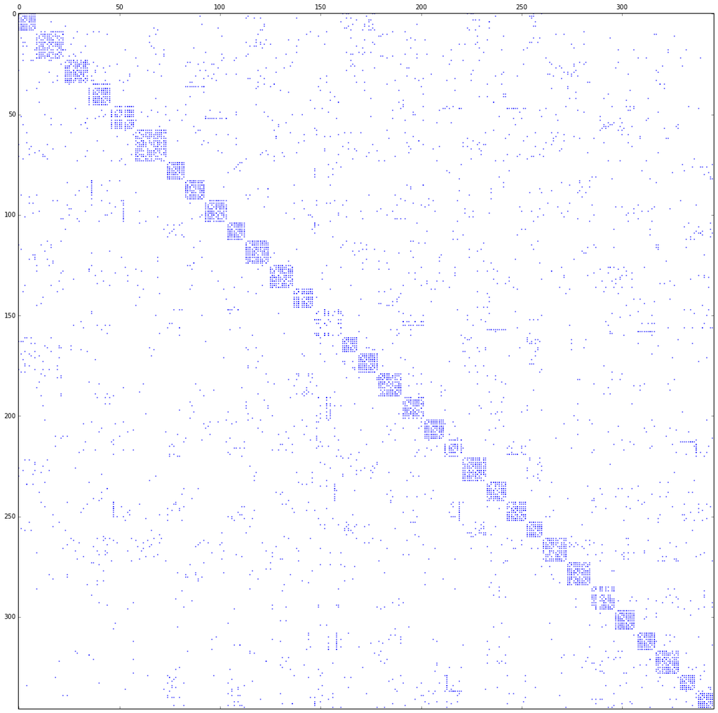

```python
plt.figure(figsize=(20,20))
plt.spy(winlossmatrix, marker='.', markersize=2)
```

We'll be using something called the *power method*. Given a random ranking `v` we'll *play* on that ranking a bunch of times (1000) to see what the outcome would be.

```python
A = winlossmatrix

# power method
v = np.random.rand(nteams,)
for i in range(0,1000):
    t=A*v
    v=t/np.linalg.norm(t)
    alph = np.dot(v,A*v)/np.dot(v,v)

I = np.argsort(v)
for t in range(1,nteams+1):
    print('%d.  %s'%(t,teamsName[I[-t]]))
```

```
1.  Kentucky
2.  North Carolina
3.  Michigan St.
4.  N.C. State
5.  Ohio St.
6.  Syracuse
7.  Duke
8.  Minnesota
9.  Connecticut
10.  Seton Hall
11.  Notre Dame
12.  Missouri
13.  Purdue
14.  Florida St.
15.  Kansas
16.  Florida
17.  Miami (FL)
18.  Virginia Tech
19.  Vanderbilt
20.  Marquette
21.  UCLA
22.  Georgia
23.  St. John's
24.  Mississippi St.
25.  Georgetown
26.  Saint Louis
27.  St. Joseph's
28.  Michigan
29.  Alabama
30.  Maryland
31.  California
32.  Arizona
33.  Cincinnati
34.  Pittsburgh
35.  Northwestern
36.  USC
37.  Wisconsin
38.  Creighton
39.  West Virginia
40.  La Salle
```

[output cut: 291 more lines]

```
332.  Central Arkansas
333.  Texas Southern
334.  SE Louisiana
335.  Prairie View A&M
336.  Southern
337.  Jackson St.
338.  AR Pine Bluff
339.  Grambling St.
340.  Alabama St.
341.  Alabama A&M
342.  Alcorn St.
343.  New Orleans
344.  Wis. Green Bay
345.  Centenary
346.  Nicholls St.
```